# Predicting Engine Failure With Hierarchical Gaussian Process

Hyunji Moon, Jungin Choi

Seoul National University

Abstract

# 0. Model Description

## GP model

$t$: age index

$j$: ship index

$k[j]$: engine index

$$y_{t,j} \sim N(\mu_{t,j},\sigma)$$
$$\mu_{t,j} = \mu + \theta_t^{\ age}+\theta_j^{\ ship}+\theta_{k[j]}^{\ engine}+\gamma_{t,j}+\delta_{t,\ k[j]}$$

$$\gamma_{j} \sim \text{MultiNormal}(0,K_{l^{\gamma},{\alpha}^{\gamma}})$$
$$\delta_{k} \sim \text{MultiNormal}(0,K_{l^{\delta},{\alpha}^{\delta}})$$
$$\theta_t^{\ age} \sim N(0, {\sigma^{age}}^2)$$
$$\theta_j^{\ ship} \sim N(0,{\sigma^{ ship}}^2\ )$$

$$\theta_k^{\ engine} \sim N(0,{\sigma^{engine}}^2\ )$$

## Stan Code

### Data, Transformed data block

```r
data {
  int<lower=1> N;
  int<lower=1> N_engines;
  int<lower=1> N_ships;
  int<lower=1> N_ages_obs;
  int<lower=1> N_ages;
  int<lower=1> ship_engine_ind[N_ships];
  int<lower=1,upper=99> ship_ind[N];
  int<lower=1> age_ind[N];
  vector[N] y;
}

transformed data {
  real ages[N_ages];
  int N_comp = 10;
  for (t in 1:N_ages)
    ages[t] = t;
}
```

### Parameters block

```r
parameters {
  matrix[N_ages,N_engines] GP_engine_std;
  matrix[N_ages,N_ships] GP_ship_std;
  vector[N_ages_obs] age_std;
  vector[N_ships] ship_std;
  vector[N_engines] engine_std;
  real<lower=0> tot_var;
  simplex[N_comp] prop_var;
  real mu;
  real<lower=0> length_GP_engine;
  real<lower=0> length_GP_ship;
  real <lower = 0> length_engine_scale;
  real <lower = 0> length_ship_scale;
  real <lower = 0> length_engine_shape;
  real <lower = 0> length_ship_shape;
}
```

- `GP_engine_std`, `GP_ship_std`, `age_std`, `ship_std`, `engine_std` follow standard normal distribution. These are tools for giving Normal prior using cholesky decomposition.
- `tot_var`and simplex `prop_var` are used to join all $\sigma$s in model in one vector.
- `mu` is $\mu$ above. ($\mu_{t,j} = \mu + \theta_t^{\ age}+\theta_j^{\ ship}+\theta_{k[j]}^{\ engine}+\gamma_{t,j}+\delta_{t,\ k[j]}$)
- `length_GP_ship`, `length_GP_engine` are length-scale of covariance matrix , i.e. $l^{\gamma}$, $l^{\delta}$.

### Transformed parameters block

```r
transformed parameters {
  matrix[N_ages,N_engines] GP_engine;
  matrix[N_ages,N_ships] GP_ship;

  vector[N_ages_obs] age_re;
  vector[N_ships] ship_re;
  vector[N_engines] engine_re;
  vector[N_comp] vars;

  real sigma_age;
  real sigma_engine;
  real sigma_ship;

  real sigma_error_ship;

  real sigma_GP_engine;
  real sigma_GP_ship;
  vars = N_comp * prop_var * tot_var;
  sigma_age = sqrt(vars[1]);
  sigma_engine = sqrt(vars[2]);
  sigma_ship = sqrt(vars[3]);
  sigma_GP_engine = sqrt(vars[4]);
  sigma_GP_ship = sqrt(vars[5]);
  sigma_error_ship = sqrt(vars[6]);

  engine_re = sigma_engine * engine_std;
  age_re = sigma_age * age_std;
  ship_re = sigma_ship * ship_std;

  {
    matrix[N_ages, N_ages] cov_engine;
    matrix[N_ages, N_ages] cov_ship;
    matrix[N_ages, N_ages] L_cov_engine;
    matrix[N_ages, N_ages] L_cov_ship;

    cov_engine = cov_exp_quad(ages, sigma_GP_engine,
                                  length_GP_engine);
    cov_ship = cov_exp_quad(ages, sigma_GP_ship,
                                  length_GP_ship);
    for (age in 1:N_ages) {
      cov_engine[age, age] = cov_engine[age, age] + 1e-6;
      cov_ship[age, age] = cov_ship[age, age] + 1e-6;
    }

    L_cov_engine = cholesky_decompose(cov_engine);
    L_cov_ship = cholesky_decompose(cov_ship);
    GP_engine = L_cov_engine * GP_engine_std; //f_engine
    GP_ship = L_cov_ship * GP_ship_std;       //f_ship
  }
}
```

- `sigma_age`, `sigma_engine`, `sigma_ship` are $\sigma^{age}$, $\sigma^{engine}$, $\sigma^{ship}$ above. $\theta_t^{\ age} \sim N(0, {\sigma^{age}}^2)$
- `sigma_GP_ship`, `sigma_GP_engine` are marginal std of covariance matrix of $\gamma_{j}$, $\delta_{k}$ i.e, ${\alpha}^{\gamma}$, ${\alpha}^{\delta}$.
- `sigma_error_ship` is $\sigma$ of $y_{t,j} \sim N(\mu_{t,j},\sigma)$.
- `engine_re = sigma_engine * engine_std` means $\theta_k^{\ engine} = \sigma^{engine}\ * N(0,1)$ so that $\theta_k^{\ engine} \sim N(0,{\sigma^{engine}}^2\ )$
- `cov_engine`, `L_cov_engine` are $K_{l^{\delta},{\alpha}^{\delta}}$ and cholesky decomposition $L_{\delta}$ so that $L_{\delta}L_{\delta}^T = K_{l^{\delta},{\alpha}^{\delta}}$
- `GP_engine = L_cov_engine * GP_engine_std` means $\delta_{k} = L_{\delta}*N(0,1)$ so that $\delta_{k} \sim \text{MultiNormal}(0,K_{l^{\delta},{\alpha}^{\delta}})$

### Model block

```r
model {
  vector[N] obs_mu;
  for (n in 1:N) {
    obs_mu[n] = mu
              + age_re[age_ind[n]]                                 //fixed effects
              + engine_re[ship_engine_ind[ship_ind[n]]]
              + ship_re[ship_ind[n]]
              + GP_engine[age_ind[n],ship_engine_ind[ship_ind[n]]] //f_engine
              + GP_ship[age_ind[n],ship_ind[n]];                   //f_ship
  }
  y ~ normal(obs_mu, sigma_error_ship);

  to_vector(GP_engine_std) ~ normal(0, 1);
  to_vector(GP_ship_std) ~ normal(0, 1);
  age_std ~ normal(0, 1);
  ship_std ~ normal(0, 1);
  engine_std ~ normal(0, 1);
  mu ~ normal(.5, .5);
  tot_var ~ normal(0,1);
  length_engine_shape ~  normal(30, 1);
  length_engine_scale ~ normal(8, 1);
  length_ship_shape ~  normal(30, 1);
  length_ship_scale ~ normal(3, 1);
  length_GP_engine ~ weibull(length_engine_shape,length_engine_scale); // (30,8)
  length_GP_ship ~ weibull(length_ship_shape,length_ship_scale); //(30,3)
}
```

- above paragraph means $\mu_{t,j} = \mu + \theta_t^{\ age}+\theta_j^{\ ship}+\theta_{k[j]}^{\ engine}+\gamma_{t,j}+\delta_{t,\ k[j]}$
- `y ~ normal(obs_mu, sigma_error_ship)` means $y_{t,j} \sim N(\mu_{t,j},\sigma)$
- `GP_engine_std`, `GP_engine_std`, `age_std`, `ship_std`, `engine_std` follow standard normal because they are used to give normal dist with cholesky.
- priors for $\mu$, $\frac{\text{sum of all $sigma$ s}}{6}$, $l^{\gamma}$, $l^{\delta}$ are given.

```r
util <- new.env()
source('stan_utility.R', local=util)
source('gp_utility.R', local=util)
```

```r
library(rstan); library(cmdstanr); library(parallel); library("tidyverse"); library(dplyr)
setwd(getwd())
set.seed(1954)
.libPaths("~/Rlib")
options(mc.cores = parallel::detectCores())
util <- new.env()
source('stan_utility.R', local=util)
source('gp_utility.R', local=util)

c_light <- c("#DCBCBC")
c_light_highlight <- c("#C79999")
c_mid <- c("#B97C7C")
c_mid_highlight <- c("#A25050")
c_dark <- c("#8F2727")
c_dark_highlight <- c("#7C0000")

c_light_trans <- c("#DCBCBC80")
c_light_highlight_trans <- c("#C7999980")
c_mid_trans <- c("#B97C7C80")
c_mid_highlight_trans <- c("#A2505080")
c_dark_trans <- c("#8F272780")
c_dark_highlight_trans <- c("#7C000080")

c_light_teal="#6B8E8E"
c_mid_teal="#487575"
c_dark_teal="#1D4F4F"

c_green_trans <- c("#00FF0080")
c_superfine <- c("#8F272705")

println <- function(msg) cat(msg); cat("\n")
```

```r
printf <- function(pattern, ...) println(sprintf(pattern, ...))
print_file <- function(file) println(readLines(file))


scriptDir <- getwd()
modelDir <- file.path(scriptDir, "models")
dataDir <- file.path(scriptDir, "data")
gp_fit <- function(modelName, data){
  chains <- 4
  parallel_chains <- min(chains, detectCores())
  scriptDir <- getwd()
  delivDir <- file.path(scriptDir, "deliv", modelName)
  prefit <- file.path(delivDir, paste0(modelName, ".rda"))
  stanfile <- file.path(modelDir, modelName, paste0(modelName, ".stan"))

  if (file.exists(prefit)){
    fit <- readRDS(prefit)
  }else{
    mod <- cmdstan_model(stanfile, quiet = FALSE)
    fit <- mod$sample(data, chains = chains, iter_warmup = 500, iter_sampling = 500,
                      parallel_chains = parallel_chains, save_warmup = FALSE)
    dir.create(delivDir)
    fit$save_object(file = prefit)
  }
  fit
}

div_detect <- function(stanfit){
  partition <- util$partition_div(stanfit)
  div_samples <- partition[[1]]
  nondiv_samples <- partition[[2]]

  par(mfrow=c(1, 3))
  plot(nondiv_samples$length_GP_engine, nondiv_samples$sigma_GP_engine, log="xy",
       col=c_dark_trans, pch=16, cex=0.8, xlab="length_GP_engine", ylab="sigma_GP_engine")
  points(div_samples$length_GP_engine, div_samples$sigma_GP_engine,
         col=c_green_trans, pch=16, cex=0.8)

  plot(nondiv_samples$length_GP_engine, nondiv_samples$sigma_error_ship,
       col=c_dark_trans, pch=16, cex=0.8, xlab="length_GP_engine", ylab="sigma_error_ship")
  points(div_samples$length_GP_engine, div_samples$sigma_error_ship,
         col=c_green_trans, pch=16, cex=0.8)

  plot(nondiv_samples$length_engine_scale, nondiv_samples$length_GP_engine_s,
       col=c_dark_trans, pch=16, cex=0.8, xlab="length_engine_scale", ylab="length_GP_engine_s")
  points(div_samples$length_engine_scale, div_samples$length_GP_engine_s,
         col=c_green_trans, pch=16, cex=0.8)
}
```

data preparation

```r
N_engines <- 5
N_ships <- 99
N_ages <- 31
N_ages_obs <- 31

ship_engine_ind <- read.csv("data/engine.csv")$engine
ship_ind <- read.csv("data/ship_index.csv")$X0
age_ind <- read.csv("data/x_age.csv", header = FALSE)[-1,1]
y <- read.csv("data/y_count_pwr.csv", header = FALSE)[,1]

data <- list(N = length(y), N_engines=N_engines,N_ships = N_ships, N_ages= N_ages, N_ages_obs = N_ages_obs,
             ship_engine_ind =ship_engine_ind, ship_ind = ship_ind, age_ind = age_ind, y=y)

mseNplot <- function(x, y){
  yhat<- x %>%
    dplyr::filter(str_detect(variable, "y_new_pred")) %>%
    pull(mean)

  yhat<- (matrix(yhat, nrow = 31, ncol = 99))
  y_hat <- rep(NA, length(y))

  for (i in 1:length(y)){
    y_hat[i] <- yhat[age_ind[i],ship_ind[i]]
  }

  par(mfrow=c(1,1))
  plot(1, type="n",xlim=c(0,31),ylim=c(-3,4),xlab="age",ylab="scaled failure count")
  for (n in 1:653){
    points(age_ind[n],y[n],col="black",pch=16)
    points(age_ind[n],y_hat[n],col="red")
  }

  mean((y-y_hat)^2)
}
```

We have started from [this](https://github.com/stan-dev/stancon_talks/tree/927ac4adb6864f256e37fa48932f28c3d31d5c2b/2017/Contributed-Talks/08_trangucci) reference code and modified based on the following steps. 1.domain knowledge, 2.prior pushforwd check, 3.prior predictive check. The last two differ in that the former’s stage is parameter space and the latter is observation, i.e. y, space.

# 1. Domain knowledge

First modifications were to simplify the model.

1. remove prop prior
2. unify trend from long and short trend
3. parameterize the `length_engine_ship` prior parameters

$\alpha$ and $\rho$ parameters could tuned with algebraic solvers match one’s domain knowledge (such as INLA example from Talts, 2018 or Mike Bentancourt’s [casestudy](https://betanalpha.github.io/assets/case_studies/gp_part3/part3.html)) but as we did not have domain knowledge on `length_engine_ship` we decided to give prior to its scale and location parameter.

> length_GP_engine ~ weibull(length_engine_shape,length_engine_scale); length_GP_ship ~ weibull(length_ship_shape,length_ship_scale);

`gp_hp.stan` is our baseline code.

# 2. Pre-predictive check

Prametrizing prevented the need for our domain knowledge but instead, we had to set reasonable prior for `length_GP_engine` and `length_GP_ship`. First attemps were just to experiment with the given parmameters in the orginal model; which ended up with divergences. > length_engine_shape ~ normal(30, 1); length_engine_scale ~ normal(8, 1); length_ship_shape ~ normal(30, 1); length_ship_scale ~ normal(3, 1);

```r
modelName <- "gp_hp"
sf_hp <- gp_fit(modelName, data)
rsf_hp <- read_stan_csv(sf_hp$output_files())
```

```r
util$check_all_diagnostics(rsf_hp)
```

```
## [1] "n_eff / iter looks reasonable for all parameters"
## [1] "Rhat looks reasonable for all parameters"
## [1] "4 of 2000 iterations ended with a divergence (0.2%)"
## [1] "  Try running with larger adapt_delta to remove the divergences"
## [1] "0 of 2000 iterations saturated the maximum tree depth of 10 (0%)"
## [1] "E-FMI indicated no pathological behavior"
```

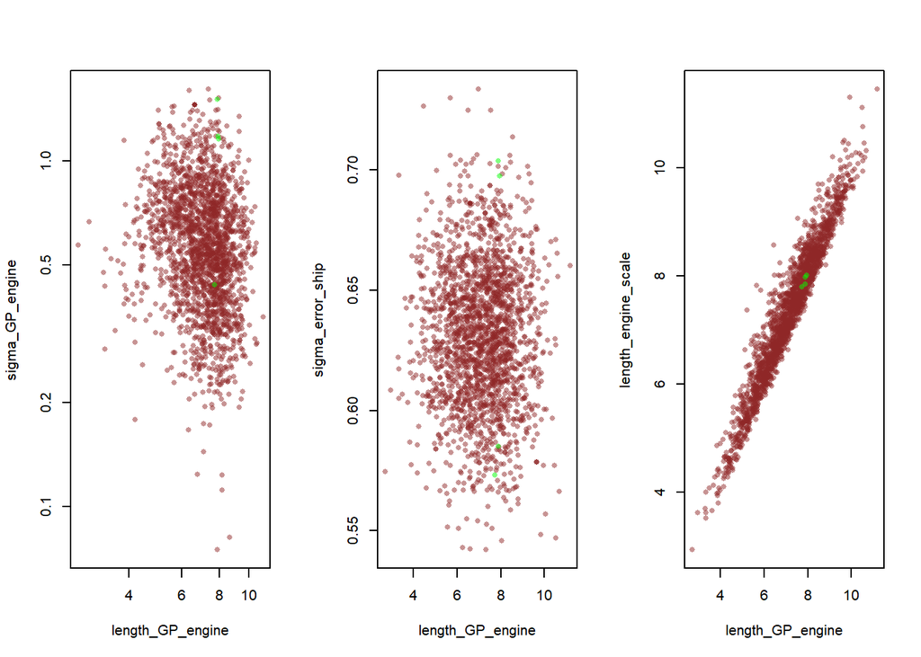

```r
partition <- util$partition_div(rsf_hp)
div_samples <- partition[[1]]
nondiv_samples <- partition[[2]]

par(mfrow=c(1, 3))
plot(nondiv_samples$length_GP_engine, nondiv_samples$sigma_GP_engine, log="xy",
       col=c_dark_trans, pch=16, cex=0.8, xlab="length_GP_engine", ylab="sigma_GP_engine")
points(div_samples$length_GP_engine, div_samples$sigma_GP_engine,
         col=c_green_trans, pch=16, cex=0.8)

plot(nondiv_samples$length_GP_engine, nondiv_samples$sigma_error_ship,
       col=c_dark_trans, pch=16, cex=0.8, xlab="length_GP_engine", ylab="sigma_error_ship")
points(div_samples$length_GP_engine, div_samples$sigma_error_ship,
         col=c_green_trans, pch=16, cex=0.8)

plot(nondiv_samples$length_GP_engine, nondiv_samples$length_engine_scale,
       col=c_dark_trans, pch=16, cex=0.8, xlab="length_GP_engine", ylab="length_engine_scale")
points(div_samples$length_GP_engine, div_samples$length_engine_scale,
         col=c_green_trans, pch=16, cex=0.8)
```

We observed two problems from the results.

## 2.1. Correlated and uneven density

When plotted, `length_GP_engine` and `length_engine_scale` showed ununiform samples which can be problematic while sampling [discourse discussion](https://discourse.mc-stan.org/t/does-uneven-pairsplot-density-indicate-reparameterization/17581/2), so we decided to reparameterize `length_GP_engine`.

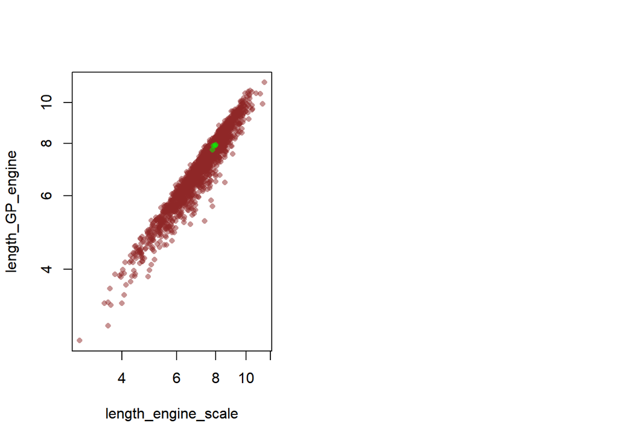

```r
partition <- util$partition_div(rsf_hp)
div_samples <- partition[[1]]
nondiv_samples <- partition[[2]]

par(mfrow=c(1, 2))
plot(nondiv_samples$length_engine_scale, nondiv_samples$length_GP_engine, log="xy",
      col=c_dark_trans, pch=16, cex=0.8, xlab="length_engine_scale", ylab="length_GP_engine")
points(div_samples$length_engine_scale, div_samples$length_GP_engine,
        col=c_green_trans, pch=16, cex=0.8)
```

Since mode and mean largely depends on scale parameter in Weibull distribution, we reparametrized `length_GP_engine` so that scale parameter is fixed to 1.

$$\rho_{engine} \sim \text{Weibull}(\alpha_{\rho},\sigma_{\rho})$$
is equivalent to

$$\rho_{engine}^s \sim \text{Weibull}(\alpha_{\rho},1)$$
$$\rho_{engine} = \rho_{engine}^s * \sigma_{\rho}$$

This is because $Y \sim \text{Weibull}(\alpha,\sigma)$ $\Rightarrow$ $kY \sim \text{Weibull}(\alpha,k\sigma)$

```stan
from
  length_GP_engine ~ weibull(length_engine_shape,length_engine_scale)
  length_GP_ship ~ weibull(length_engine_ship,length_engine_ship)

to

  real length_GP_engine = length_engine_scale * length_GP_engine_s;
  real length_GP_ship = length_ship_scale * length_GP_ship_s;
  length_GP_engine_s ~ weibull(length_engine_shape,1);
  length_GP_ship_s ~ weibull(length_ship_shape,1);
```

```r
modelName <- "gp_reparam"


sf_reparam <- gp_fit(modelName, data)
rsf_reparam <- read_stan_csv(sf_reparam$output_files())
```

```r
util$check_all_diagnostics(rsf_reparam)
```

```
## [1] "n_eff / iter looks reasonable for all parameters"
## [1] "Rhat looks reasonable for all parameters"
## [1] "0 of 2000 iterations ended with a divergence (0%)"
## [1] "0 of 2000 iterations saturated the maximum tree depth of 10 (0%)"
## [1] "E-FMI indicated no pathological behavior"
```

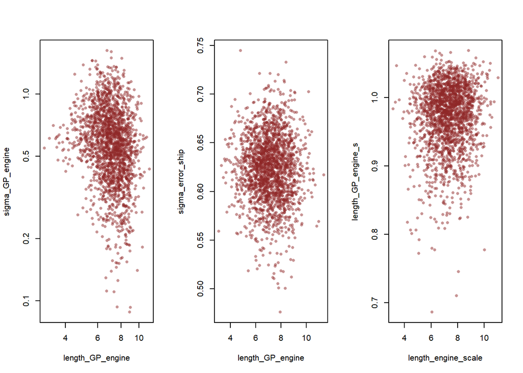

```r
div_detect(rsf_reparam)
```

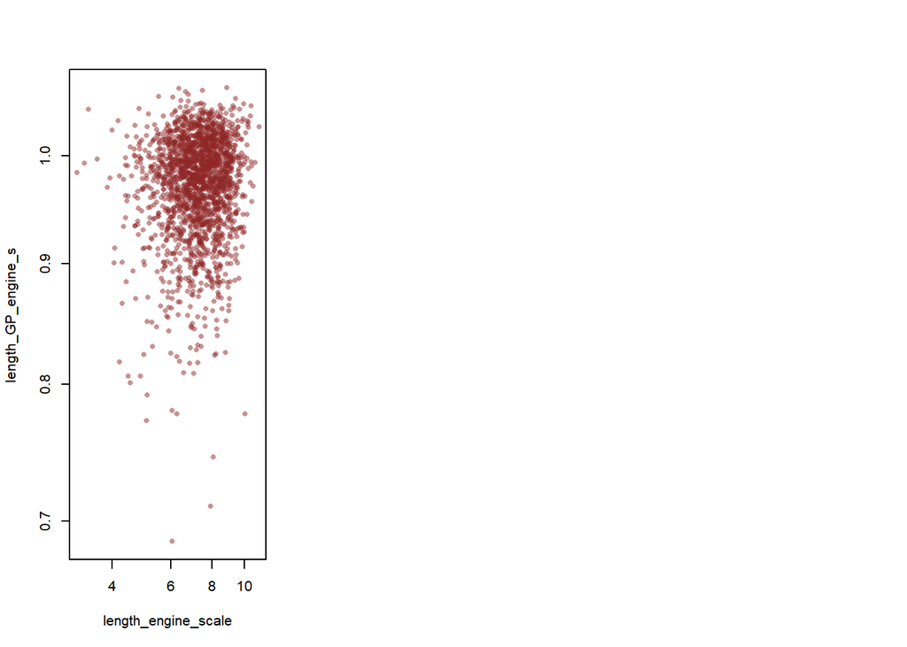

```r
partition <- util$partition_div(rsf_reparam)
div_samples <- partition[[1]]
nondiv_samples <- partition[[2]]

par(mfrow=c(1, 3))
plot(nondiv_samples$length_engine_scale, nondiv_samples$length_GP_engine_s, log="xy",
      col=c_dark_trans, pch=16, cex=0.8, xlab="length_engine_scale", ylab="length_GP_engine_s")
points(div_samples$length_engine_scale, div_samples$length_GP_engine_s,
        col=c_green_trans, pch=16, cex=0.8)
```

The reparameterization has led to more even plot.

## 2.2. Identification problems

As can be seen from the result, the value does not change much from the given prior values, which could indicate identification issues (refer to Bentancourt’s [identity crisis](https://betanalpha.github.io/assets/case_studies/identifiability.html)). This might be due to the fact that data are scaled for security issues and have relatively weak impact on the prior update. Therefore, to investigate the parameters’ true range, weak priors are given. We chose $lognormal(0,3)$.

```stan
length_engine_scale ~ lognormal(0, 3);
length_ship_scale ~ lognormal(0, 3);
length_engine_shape ~  lognormal(0, 3);
length_ship_shape ~  lognormal(0, 3);
```

```r
modelName <- "gp_hp_lognorm"
data$hp_scale <- 3
sf_hp_ln <- gp_fit(modelName, data)
rsf_hp_ln <- read_stan_csv(sf_hp_ln$output_files())
```

```r
util$check_all_diagnostics(rsf_hp_ln)
```

```
## [1] "n_eff / iter looks reasonable for all parameters"
## [1] "Rhat for parameter length_GP_ship is 1.13027917437218!"
## [1] "  Rhat above 1.1 indicates that the chains very likely have not mixed"
## [1] "271 of 2000 iterations ended with a divergence (13.55%)"
## [1] "  Try running with larger adapt_delta to remove the divergences"
## [1] "349 of 2000 iterations saturated the maximum tree depth of 10 (17.45%)"
## [1] "  Run again with max_treedepth set to a larger value to avoid saturation"
## [1] "E-FMI indicated no pathological behavior"
```

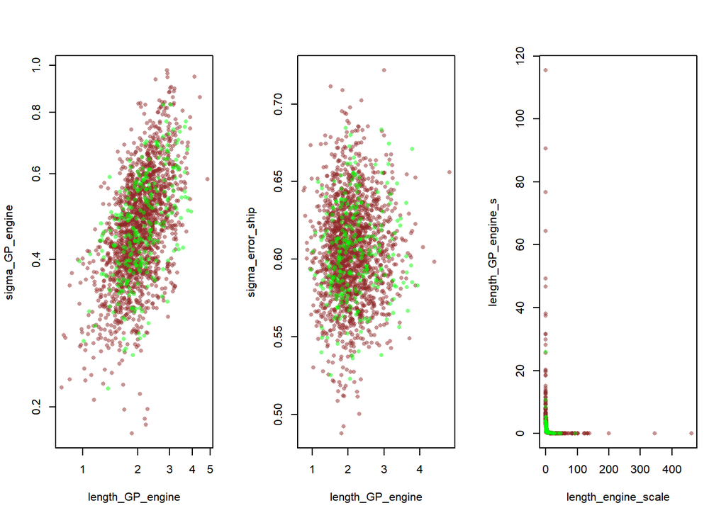

```r
div_detect(rsf_hp_ln)
```

```r
emp_le_shape <-sf_hp_ln$summary("length_engine_shape")%>% pull(mean)
emp_le_scale <-sf_hp_ln$summary("length_engine_scale")%>% pull(mean)
emp_ls_shape <-sf_hp_ln$summary("length_ship_shape")%>% pull(mean)
emp_ls_scale <-sf_hp_ln$summary("length_ship_scale")%>% pull(mean)
print(c(emp_le_shape, emp_le_scale, emp_ls_shape,emp_ls_scale))
```

```
## [1] 18.725967  5.773572 11.603859  8.269962
```

Restricting the range of `length_engine_*` and `length_ship_*` is needed to address divergence problems. We decided to plug in the empirical values.

```r
modelName <- "gp_hp_norm"
data$hp_scale <- 1
data$emp_le_shape <- emp_le_shape
data$emp_le_scale <- emp_le_scale
data$emp_ls_shape <- emp_ls_shape
data$emp_ls_scale <- emp_ls_scale
sf_hp_n <- gp_fit(modelName, data)
rsf_hp_n <- read_stan_csv(sf_hp_n$output_files())
```

```r
util$check_all_diagnostics(rsf_hp_n)
```

```
## [1] "n_eff / iter looks reasonable for all parameters"
## [1] "Rhat looks reasonable for all parameters"
## [1] "0 of 2000 iterations ended with a divergence (0%)"
## [1] "0 of 2000 iterations saturated the maximum tree depth of 10 (0%)"
## [1] "E-FMI indicated no pathological behavior"
```

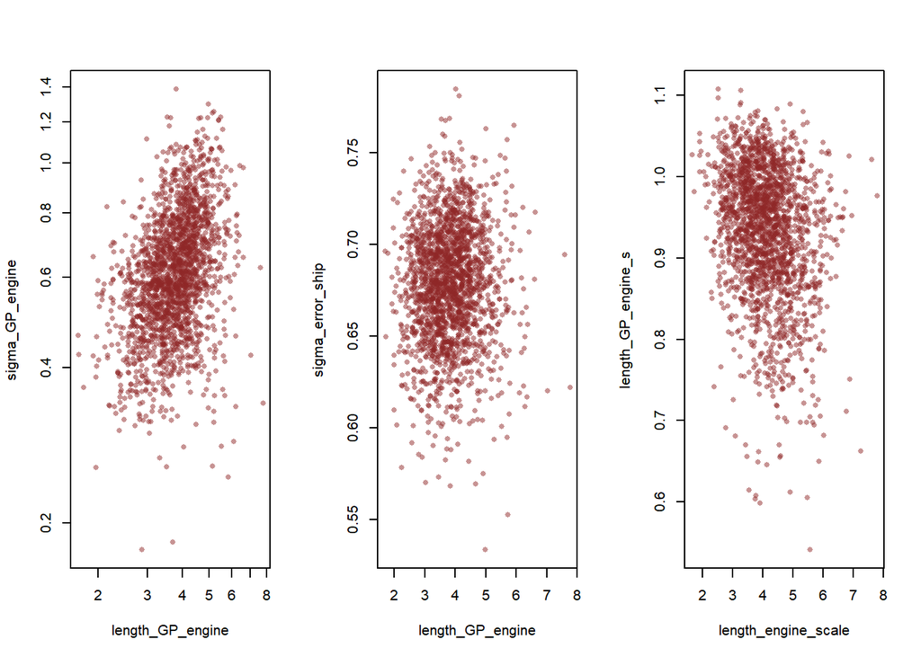

```r
div_detect(rsf_hp_n)
```

```r
emp_le_shape_2 <-sf_hp_n$summary("length_engine_shape")%>% pull(mean)
emp_le_scale_2 <-sf_hp_n$summary("length_engine_scale")%>% pull(mean)
emp_ls_shape_2 <-sf_hp_n$summary("length_ship_shape")%>% pull(mean)
emp_ls_scale_2 <-sf_hp_n$summary("length_ship_scale")%>% pull(mean)
print(c(emp_le_shape_2, emp_le_scale_2, emp_ls_shape_2,emp_ls_scale_2))
```

```
## [1] 18.707524  4.120272 11.289554  6.821292
```

As this resulted in less divergence, we set this value as our prior parameters for further experiment.

```r
data$emp_le_shape <- emp_le_shape_2
data$emp_le_scale <- emp_le_scale_2
data$emp_ls_shape <- emp_ls_shape_2
data$emp_ls_scale <- emp_ls_scale_2
```

# 3. Predictive checks

## 3.1. Different $\sigma$ for each engine

From the plot, our $\tilde{y}$ seems to be different from y, real data. Below is how we updated the model iteratively to make our $\tilde{y}$ closer to y.

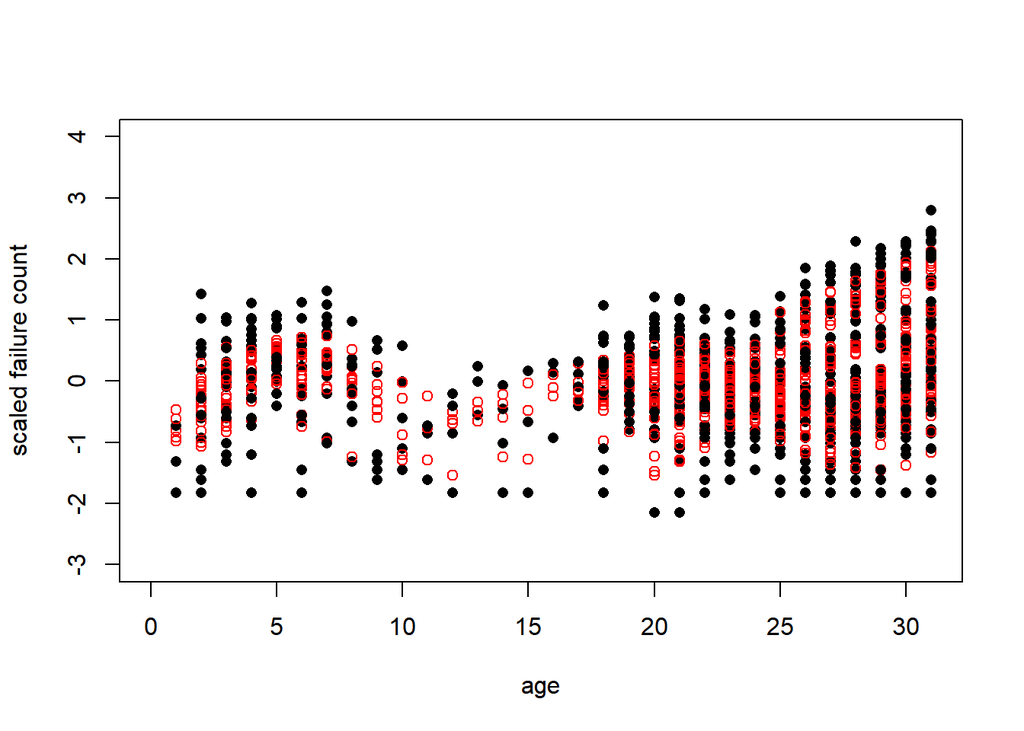

```r
sf_hp_n_sm <- sf_hp_n$summary()
mse_hp_n <- mseNplot(sf_hp_n_sm,y)
```

```r
mse_hp_n
```

```
## [1] 0.3511693
```

For each lifetime, standard deviation for each engine looks quite different. For example, engine 4 and 5 shows large variance while engine 3 shows small variance of given data. We attempted to give different errors to each engine.
$$y_{t,j} \sim Normal(\mu_{t,j},\sigma_{k[j]})$$

```stan
transformed parameters {
  real sigma_error_ship -> real sigma_error_ship[5]
}

model{
  for (i in 1:5)
      sigma_error_ship[i] = sqrt(vars[i + 5]);

  y[n] ~ normal(obs_mu[n], sigma_error_ship[ship_engine_ind[ship_ind[n]]])
}
```

```r
modelName <- "gp_hp_n_5var"

sf_gp_hp_n_5var <- gp_fit(modelName, data)
rsf_gp_hp_n_5var <- read_stan_csv(sf_gp_hp_n_5var$output_files())
```

```r
util$check_all_diagnostics(rsf_gp_hp_n_5var)
```

```
## [1] "n_eff / iter looks reasonable for all parameters"
## [1] "Rhat for parameter length_GP_ship is 1.12088734806734!"
## [1] "  Rhat above 1.1 indicates that the chains very likely have not mixed"
## [1] "0 of 2000 iterations ended with a divergence (0%)"
## [1] "0 of 2000 iterations saturated the maximum tree depth of 10 (0%)"
## [1] "E-FMI indicated no pathological behavior"
```

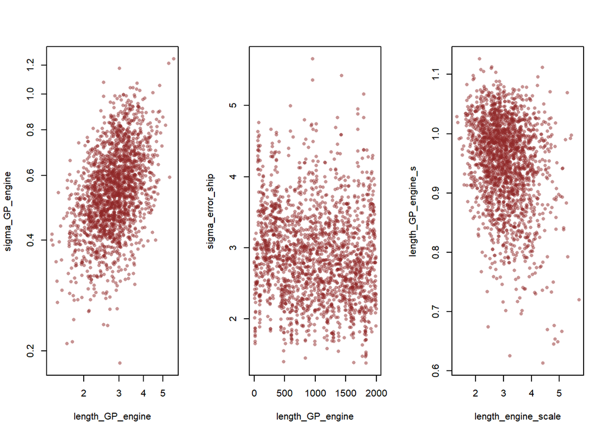

```r
div_detect(rsf_gp_hp_n_5var)
```

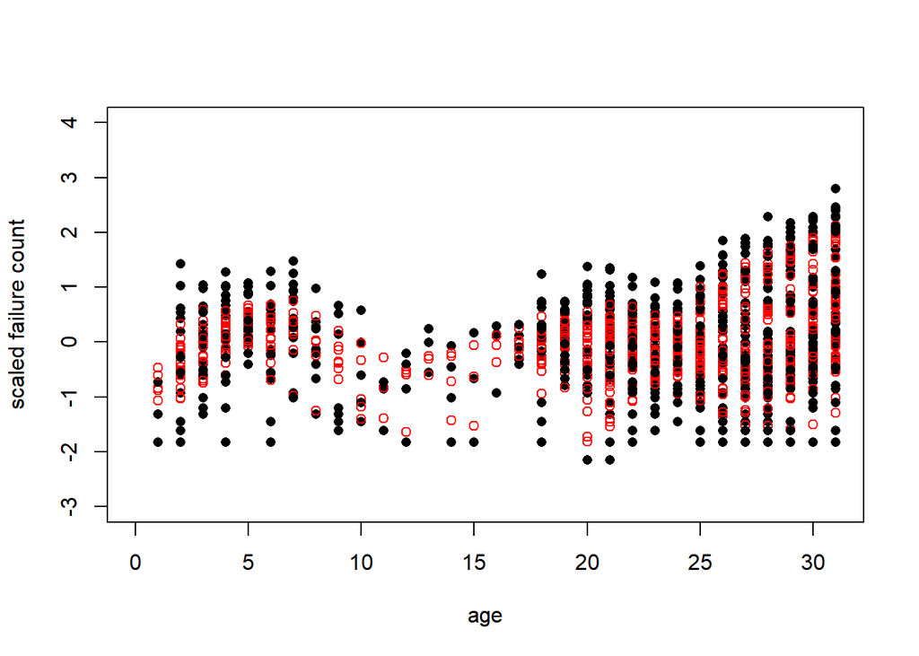

```r
sf_gp_hp_n_5var_sm<-sf_gp_hp_n_5var$summary()

mse_res_n_5var <- mseNplot(sf_gp_hp_n_5var_sm,y)
```

```r
mse_res_n_5var
```

```
## [1] 0.3133182
```

We decided to use the different variance for each engine.

# Conclusion

Further developement are as follows:

1. Phase-type distribution could be applied to represent different characteric of each era.
2. Bayesian model averaging between different model structure (splines & GP) and additional features that could affect engine failure such as ship size or operation time.
3. latent Gaussian model with Poisson likelihood could be used and as additional data are expected, approximation model such as adjoint-differentiation(Margossian, 2020) could be considered.

# References

Trangucci (2017). Hierarchical Gaussian processes in Stan

Margossian, C. C., Vehtari, A., Simpson, D., & Agrawal, R. (2020). Hamiltonian Monte Carlo using an adjoint-differentiated Laplace approximation. arXiv preprint arXiv:2004.12550.